# Exercise 1

Shaqed Carasso

ID: 201281805

10/28/2021

## Computations in R

1. Sum 2 and 3 using the + operator.

```r
2+3
```

```
## [1] 5
```

2. Take the square root of 36, use sqrt().

```r
sqrt(36)
```

```
## [1] 6
```

3. Take the log10 of 1000, use function log10().

```r
log10(1000)
```

```
## [1] 3
```

4. Take the log2 of 32, use function log2().

```r
log2(32)
```

```
## [1] 5
```

5. Assign the sum of 2,3 and 4 to variable x.

```r
x = 2+3+4
x
```

```
## [1] 9
```

6. Find the absolute value of the expression 5 - 145 using the abs() function.

```r
abs(5-145)
```

```
## [1] 140
```

7. Calculate the square root of 625, divide it by 5, and assign it to variable x.

```r
x = sqrt(625)/5
x
```

```
## [1] 5
```

8. Multiply the value you get from previous exercise by 10000, assign it to variable x

```r
x = 10000*x
x
```

```
## [1] 50000
```

## Data structures in R

```r
vec = c(1,2,3,5)
vec
```

```
## [1] 1 2 3 5
```

11. Check the length of your vector with length(). Ex: length(vec1) should return 3.

```r
length(vec)
```

```
## [1] 4
```

12. Make a vector of all numbers between 2 and 15.

```r
c(2:15)
```

```
##  [1]  2  3  4  5  6  7  8  9 10 11 12 13 14 15
```

13. Make a vector of 4s repeated 10 times using the rep() function.

```r
rep(x = 4, times = 10)
```

```
##  [1] 4 4 4 4 4 4 4 4 4 4
```

14. Make a logical vector with TRUE, FALSE values of length 4, use c().

```r
c(T,T,T,F)
```

```
## [1]  TRUE  TRUE  TRUE FALSE
```

15. Make a character vector of the gene names PAX6,ZIC2,OCT4 and SOX2.

```r
avec = c("PAX6", "ZIC2", "OCT4", "SOX2")
avec
```

```
## [1] "PAX6" "ZIC2" "OCT4" "SOX2"
```

16. Subset the vector using [] notation, and get the 5th and 6th elements.

```r
avec[c(5,6)]
```

```
## [1] NA NA
```

17. You can also subset any vector using a logical vector in []. Run the following:

```r
myvec=1:5
# the length of the logical vector
# should be equal to length(myvec)
myvec[c(TRUE,TRUE,FALSE,FALSE,FALSE)]
```

```
## [1] 1 2
```

```r
myvec[c(TRUE,FALSE,FALSE,FALSE,TRUE)]
```

```
## [1] 1 5
```

18. ==,>,<, >=, <= operators create logical vectors. See the results of the following operations:

```r
myvec > 3
```

```
## [1] FALSE FALSE FALSE  TRUE  TRUE
```

```r
myvec == 4
```

```
## [1] FALSE FALSE FALSE  TRUE FALSE
```

```r
myvec <= 2
```

```
## [1]  TRUE  TRUE FALSE FALSE FALSE
```

```r
myvec != 4
```

```
## [1]  TRUE  TRUE  TRUE FALSE  TRUE
```

19. Use the > operator in myvec[ ] to get elements larger than 2 in myvec which is described above.

```r
myvec[myvec > 2]
```

```
## [1] 3 4 5
```

20. Make a 5x3 matrix (5 rows, 3 columns) using matrix().

```r
mat = matrix(1:15, nrow = 5, ncol = 3)
mat
```

```
##      [,1] [,2] [,3]
## [1,]    1    6   11
## [2,]    2    7   12
## [3,]    3    8   13
## [4,]    4    9   14
## [5,]    5   10   15
```

21. What happens when you use byrow = TRUE in your matrix() as an additional argument?

```r
mat = matrix(1:15, nrow = 5, ncol = 3, byrow = TRUE)
mat
```

```
##      [,1] [,2] [,3]
## [1,]    1    2    3
## [2,]    4    5    6
## [3,]    7    8    9
## [4,]   10   11   12
## [5,]   13   14   15
```

22. Extract the first 3 columns and first 3 rows of your matrix using [] notation.

```r
mat[1:3,1:3]
```

```
##      [,1] [,2] [,3]
## [1,]    1    2    3
## [2,]    4    5    6
## [3,]    7    8    9
```

23. Extract the last two rows of the matrix you created earlier.

```r
mat[4:5,]
```

```
##      [,1] [,2] [,3]
## [1,]   10   11   12
## [2,]   13   14   15
```

24. Extract the first two columns and run class() on the result.

```r
class(mat[,1:2])
```

```
## [1] "matrix" "array"
```

25. Extract the first column and run class() on the result, compare with the above exercise.

```r
class(mat[,1])
```

```
## [1] "integer"
```

26. Make a data frame with 3 columns and 5 rows. Make sure first column is a sequence of numbers 1:5, and second column is a character vector.

```r
df=data.frame(col1=1:5,col2=c("a","b","c","S","C"),col3=46:50)
df
```

```
##   col1 col2 col3
## 1    1    a   46
## 2    2    b   47
## 3    3    c   48
## 4    4    S   49
## 5    5    C   50
```

27. Extract the first two columns and first two rows. HINT: Use the same notation as matrices.

```r
df[1:2,1:2]
```

```
##   col1 col2
## 1    1    a
## 2    2    b
```

28. Extract the last two rows of the data frame you made. HINT: Same notation as matrices.

```r
df[4:5,]
```

```
##   col1 col2 col3
## 4    4    S   49
## 5    5    C   50
```

29. Extract the last two columns using the column names of the data frame you made.

```r
df[,c("col2", "col3")]
```

```
##   col2 col3
## 1    a   46
## 2    b   47
## 3    c   48
## 4    S   49
## 5    C   50
```

30. Extract the second column using the column names. You can use [] or $ as in lists; use both in two different answers.

```r
df$col2
```

```
## [1] "a" "b" "c" "S" "C"
```

```r
df[,"col2"]
```

```
## [1] "a" "b" "c" "S" "C"
```

31. Extract rows where the 1st column is larger than 3.

```r
df[df$col1>3,]
```

```
##   col1 col2 col3
## 4    4    S   49
## 5    5    C   50
```

32. Extract rows where the 1st column is larger than or equal to 3.

```r
df[df$col1>=3,]
```

```
##   col1 col2 col3
## 3    3    c   48
## 4    4    S   49
## 5    5    C   50
```

33. Convert a data frame to the matrix. HINT: Use as.matrix(). Observe what happens to numeric values in the data frame.

```r
as.matrix(df)
```

```
##      col1 col2 col3
## [1,] "1"  "a"  "46"
## [2,] "2"  "b"  "47"
## [3,] "3"  "c"  "48"
## [4,] "4"  "S"  "49"
## [5,] "5"  "C"  "50"
```

34. Make a list using the list() function. Your list should have 4 elements; the one below has 2.

```r
mylist = list(a=c(1,2,3),
             b=c("apple","orange"),
             c=c("Maccabi","Haifa"),
             d=c("Champs", "2020-2021"))
mylist
```

```
## $a
## [1] 1 2 3
##
## $b
## [1] "apple"  "orange"
##
## $c
## [1] "Maccabi" "Haifa"
##
## $d
## [1] "Champs"    "2020-2021"
```

35. Select the 1st element of the list you made using $ notation.

```r
mylist$a
```

```
## [1] 1 2 3
```

36. Select the 4th element of the list you made earlier using $ notation.

```r
mylist$d
```

```
## [1] "Champs"    "2020-2021"
```

37. Select the 1st element of your list using [ ] notation.

```r
mylist["a"]
```

```
## $a
## [1] 1 2 3
```

38. Select the 4th element of your list using [ ] notation.

```r
mylist["d"]
```

```
## $d
## [1] "Champs"    "2020-2021"
```

39. Make a factor using factor(), with 5 elements.

```r
fa = factor(c("1", "2", "3", "4", "5"))
fa
```

```
## [1] 1 2 3 4 5
## Levels: 1 2 3 4 5
```

40. Convert a character vector to a factor using as.factor(). First, make a character vector using c() then use as.factor().

```r
cvec = c("c","h","a","r")
cvec
```

```
## [1] "c" "h" "a" "r"
```

```r
cvec_fac = as.factor(cvec)
cvec_fac
```

```
## [1] c h a r
## Levels: a c h r
```

41. Convert the factor you made above to a character using as.character().

```r
as.character(cvec_fac)
```

```
## [1] "c" "h" "a" "r"
```

## Reading in and writing data out in R

1. Read CpG island (CpGi) data from the compGenomRData package CpGi.table.hg18.txt. This is a tab-separated file. Store it in a variable called cpgi.

```r
cpgFilePath=system.file("extdata", "CpGi.table.hg18.txt", package="compGenomRData")
cpgi=read.table(cpgFilePath, header=TRUE, sep="\t")
```

2. Use head() on CpGi to see the first few rows.

```r
head(cpgi)
```

```
##   chrom chromStart chromEnd     name length cpgNum gcNum perCpg perGc obsExp
## 1  chr1      18598    19673 CpG: 116   1075    116   787   21.6  73.2   0.83
## 2  chr1     124987   125426  CpG: 30    439     30   295   13.7  67.2   0.64
## 3  chr1     317653   318092  CpG: 29    439     29   295   13.2  67.2   0.62
## 4  chr1     427014   428027  CpG: 84   1013     84   734   16.6  72.5   0.64
## 5  chr1     439136   440407  CpG: 99   1271     99   777   15.6  61.1   0.84
## 6  chr1     523082   523977  CpG: 94    895     94   570   21.0  63.7   1.04
```

3. Why doesn’t the following work? See sep argument at help(read.table).  
   *Doesn’t work because the delimiter is tab and not a comma.*

```r
cpgiSepComma=read.table(cpgFilePath, header=TRUE,sep=",")
head(cpgiSepComma)
```

```
##   chrom.chromStart.chromEnd.name.length.cpgNum.gcNum.perCpg.perGc.obsExp
## 1                  chr1\t18598\t19673\tCpG: 116\t1075\t116\t787\t21.6\t73.2\t0.83
## 2                   chr1\t124987\t125426\tCpG: 30\t439\t30\t295\t13.7\t67.2\t0.64
## 3                   chr1\t317653\t318092\tCpG: 29\t439\t29\t295\t13.2\t67.2\t0.62
## 4                  chr1\t427014\t428027\tCpG: 84\t1013\t84\t734\t16.6\t72.5\t0.64
## 5                  chr1\t439136\t440407\tCpG: 99\t1271\t99\t777\t15.6\t61.1\t0.84
## 6                     chr1\t523082\t523977\tCpG: 94\t895\t94\t570\t21\t63.7\t1.04
```

4. What happens when you set stringsAsFactors=FALSE in read.table()?  
   *Strings, like the chromosomes’ names, won’t be converted to factors.*

```r
cpgiHF=read.table(cpgFilePath, header=TRUE, sep="\t", stringsAsFactors=FALSE)
head(cpgiHF)
```

```
##   chrom chromStart chromEnd     name length cpgNum gcNum perCpg perGc obsExp
## 1  chr1      18598    19673 CpG: 116   1075    116   787   21.6  73.2   0.83
## 2  chr1     124987   125426  CpG: 30    439     30   295   13.7  67.2   0.64
## 3  chr1     317653   318092  CpG: 29    439     29   295   13.2  67.2   0.62
## 4  chr1     427014   428027  CpG: 84   1013     84   734   16.6  72.5   0.64
## 5  chr1     439136   440407  CpG: 99   1271     99   777   15.6  61.1   0.84
## 6  chr1     523082   523977  CpG: 94    895     94   570   21.0  63.7   1.04
```

5. Read only the first 10 rows of the CpGi table.

```r
cpgi_10rows=read.table(cpgFilePath, header=TRUE, nrows = 10, sep="\t")
dim(cpgi_10rows)
```

```
## [1] 10 10
```

```r
head(cpgi_10rows)
```

```
##   chrom chromStart chromEnd     name length cpgNum gcNum perCpg perGc obsExp
## 1  chr1      18598    19673 CpG: 116   1075    116   787   21.6  73.2   0.83
## 2  chr1     124987   125426  CpG: 30    439     30   295   13.7  67.2   0.64
## 3  chr1     317653   318092  CpG: 29    439     29   295   13.2  67.2   0.62
## 4  chr1     427014   428027  CpG: 84   1013     84   734   16.6  72.5   0.64
## 5  chr1     439136   440407  CpG: 99   1271     99   777   15.6  61.1   0.84
## 6  chr1     523082   523977  CpG: 94    895     94   570   21.0  63.7   1.04
```

6. Use cpgFilePath=system.file(“extdata”,“CpGi.table.hg18.txt”, package=“compGenomRData”) to get the file path, then use read.table() with argument header=FALSE. Use head() to see the results.  
   *Headers are now just a regular row.*

```r
cpgi_no_header=read.table(cpgFilePath, header=FALSE, sep="\t")
head(cpgi_no_header)
```

```
##      V1         V2       V3       V4     V5     V6    V7     V8    V9    V10
## 1 chrom chromStart chromEnd     name length cpgNum gcNum perCpg perGc obsExp
## 2  chr1      18598    19673 CpG: 116   1075    116   787   21.6  73.2   0.83
## 3  chr1     124987   125426  CpG: 30    439     30   295   13.7  67.2   0.64
## 4  chr1     317653   318092  CpG: 29    439     29   295   13.2  67.2   0.62
## 5  chr1     427014   428027  CpG: 84   1013     84   734   16.6  72.5   0.64
## 6  chr1     439136   440407  CpG: 99   1271     99   777   15.6  61.1   0.84
```

7. Write CpG islands to a text file called “my.cpgi.file.txt”. Write the file to your home folder.

```r
write.table(cpgi, "my.cpgi.file.txt")
write.table(cpgi, "my.cpgi.file2.txt", quote=FALSE,sep="\t")
```

9. Write out the first 10 rows of the cpgi data frame. HINT: Use subsetting for data frames we learned before.

```r
write.table(cpgi[1:10,], "my.cpgi.file_10rows.txt", quote=FALSE,sep="\t")
```

10. Write the first 3 columns of the cpgi data frame.

```r
write.table(cpgi[,1:3], "my.cpgi.file_3cols.txt", quote=FALSE,sep="\t")
```

11. Write CpG islands only on chr1. HINT: Use subsetting with [], feed a logical vector using == operator.

```r
write.table(cpgi[cpgi$chrom == "chr1",], "my.cpgi.file_chr1.txt", quote=FALSE,sep="\t")
```

12. Read two other data sets “rn4.refseq.bed” and “rn4.refseq2name.txt” with header=FALSE, and assign them to df1 and df2 respectively. They are again included in the compGenomRData package, and you can use the system.file() function to get the file paths.

```r
rn4File1Path=system.file("extdata", "rn4.refseq.bed", package="compGenomRData")
rn4File2Path=system.file("extdata", "rn4.refseq.bed", package="compGenomRData")
df1 = read.table(rn4File1Path, header=FALSE)
df2 = read.table(rn4File2Path, header=FALSE)
```

13. Use head() to see what is inside the data frames above.

```r
head(df1)
```

```
##     V1        V2        V3           V4 V5 V6        V7        V8 V9 V10
## 1 chr1 133925506 134302139 NM_001270655  0  - 133925682 134302088  0  18
## 2 chr1 133925506 134302139    NM_019248  0  - 133925682 134302088  0  17
## 3 chr1 133925506 134302139 NM_001270656  0  - 133925682 134302088  0  19
## 4 chr1 109047398 109277756    NM_017065  0  + 109047398 109277253  0   8
## 5 chr1  99805921 100758002    NM_031069  0  +  99805979 100757606  0  20
## 6 chr1  83873577  83896121 NM_001008368  0  +  83878366  83895596  0  15
##                                                                          V11
## 1         362,159,42,244,173,131,189,103,65,24,297,142,143,158,69,72,75,299,
## 2            362,159,244,173,131,189,103,65,24,297,142,143,158,69,72,75,299,
## 3      362,159,42,75,244,173,131,189,103,65,24,297,142,143,158,69,72,75,299,
## 4                                              94,68,221,83,138,153,245,845,
## 5 113,129,21,171,97,73,83,135,103,74,100,129,126,123,96,141,194,177,225,447,
## 6                         418,49,114,42,107,57,69,130,60,56,77,52,71,67,675,
##                                                                                                                                     V12
## 1                   0,7463,12607,52937,56395,65765,155928,243845,244836,247109,253250,253995,254526,255726,271163,312060,312864,376334,
## 2                         0,7463,52937,56395,65765,155928,243845,244836,247109,253250,253995,254526,255726,271163,312060,312864,376334,
## 3             0,7463,12607,34059,52937,56395,65765,155928,243845,244836,247109,253250,253995,254526,255726,271163,312060,312864,376334,
## 4                                                                                      0,290,169006,190961,194261,216984,221138,229513,
## 5 0,8713,167962,220742,259227,310308,311027,320653,321884,333564,344390,363454,529322,641329,755627,914417,935329,942335,944485,951634,
## 6                                                  0,4741,5033,10409,10551,10744,12328,17086,19398,19674,19814,19972,21540,21719,21869,
```

```r
head(df2)
```

```
##     V1        V2        V3           V4 V5 V6        V7        V8 V9 V10
## 1 chr1 133925506 134302139 NM_001270655  0  - 133925682 134302088  0  18
## 2 chr1 133925506 134302139    NM_019248  0  - 133925682 134302088  0  17
## 3 chr1 133925506 134302139 NM_001270656  0  - 133925682 134302088  0  19
## 4 chr1 109047398 109277756    NM_017065  0  + 109047398 109277253  0   8
## 5 chr1  99805921 100758002    NM_031069  0  +  99805979 100757606  0  20
## 6 chr1  83873577  83896121 NM_001008368  0  +  83878366  83895596  0  15
##                                                                          V11
## 1         362,159,42,244,173,131,189,103,65,24,297,142,143,158,69,72,75,299,
## 2            362,159,244,173,131,189,103,65,24,297,142,143,158,69,72,75,299,
## 3      362,159,42,75,244,173,131,189,103,65,24,297,142,143,158,69,72,75,299,
## 4                                              94,68,221,83,138,153,245,845,
## 5 113,129,21,171,97,73,83,135,103,74,100,129,126,123,96,141,194,177,225,447,
## 6                         418,49,114,42,107,57,69,130,60,56,77,52,71,67,675,
##                                                                                                                                     V12
## 1                   0,7463,12607,52937,56395,65765,155928,243845,244836,247109,253250,253995,254526,255726,271163,312060,312864,376334,
## 2                         0,7463,52937,56395,65765,155928,243845,244836,247109,253250,253995,254526,255726,271163,312060,312864,376334,
## 3             0,7463,12607,34059,52937,56395,65765,155928,243845,244836,247109,253250,253995,254526,255726,271163,312060,312864,376334,
## 4                                                                                      0,290,169006,190961,194261,216984,221138,229513,
## 5 0,8713,167962,220742,259227,310308,311027,320653,321884,333564,344390,363454,529322,641329,755627,914417,935329,942335,944485,951634,
## 6                                                  0,4741,5033,10409,10551,10744,12328,17086,19398,19674,19814,19972,21540,21719,21869,
```

14. Merge data sets using merge() and assign the results to a variable named ‘new.df’, and use head() to see the results.

```r
new.df = merge(df1,df2)
head(new.df)
```

```
##     V1        V2        V3           V4 V5 V6        V7        V8 V9 V10
## 1 chr1 100482037 100483507 NM_001103363  0  + 100482070 100483258  0   1
## 2 chr1   1009411   1021923 NM_001099460  0  +   1009411   1021923  0   6
## 3 chr1 101425974 101466023    NM_053427  0  + 101426436 101464264  0  12
## 4 chr1 101697264 101798495 NM_001127504  0  + 101697363 101797483  0   7
## 5 chr1 101803004 101808694 NM_001271084  0  - 101803831 101808573  0   4
## 6 chr1 101818826 101822727 NM_001195599  0  - 101818970 101822711  0   4
##                                               V11
## 1                                           1470,
## 2                        206,283,804,225,124,884,
## 3 548,253,119,115,88,87,143,150,133,111,128,2095,
## 4                    247,122,142,64,142,108,1231,
## 5                                 842,111,51,175,
## 6                                  153,105,45,61,
##                                                                  V12
## 1                                                                 0,
## 2                                      0,6524,7232,8886,10339,11628,
## 3 0,3294,4890,20953,22131,23882,26857,30425,35048,36464,36938,37954,
## 4                             0,9425,33100,43255,50933,58282,100000,
## 5                                                  0,3263,3770,5515,
## 6                                                  0,1677,3052,3840,
```

## Plotting in R

Please run the following code snippet for the rest of the exercises.

```r
set.seed(1001)
x1=1:100+rnorm(100,mean=0,sd=15)
y1=1:100
```

1. Make a scatter plot using the x1 and y1 vectors generated above.
2. Use the main argument to give a title to plot() as in plot(x,y,main=“title”).
3. Use the xlab argument to set a label for the x-axis. Use ylab argument to set a label for the y-axis.
4. Once you have the plot, run the following expression in R console. mtext(side=3,text=“hi there”) does.

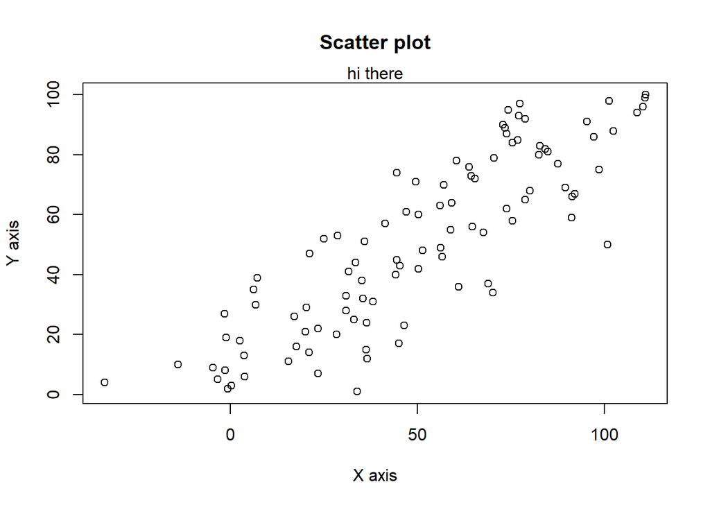

```r
plot(x1,y1, main = "Scatter plot", xlab = "X axis", ylab = "Y axis")
mtext(side=3,text="hi there")
```

5. See what mtext(side=2,text=“hi there”) does. Check your plot after execution.

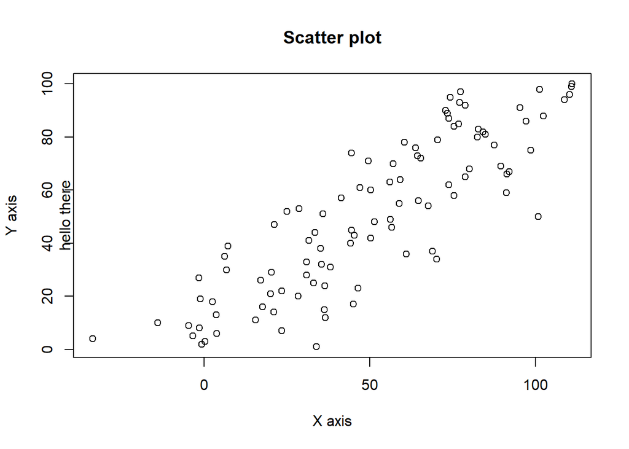

```r
plot(x1,y1, main = "Scatter plot", xlab = "X axis", ylab = "Y axis")
mtext(side=2,text="hello there")
```

6. Use mtext() and paste() to put a margin text on the plot. You can use paste() as ‘text’ argument in mtext(). HINT: mtext(side=3,text=paste(…)). See how paste() is used for below.

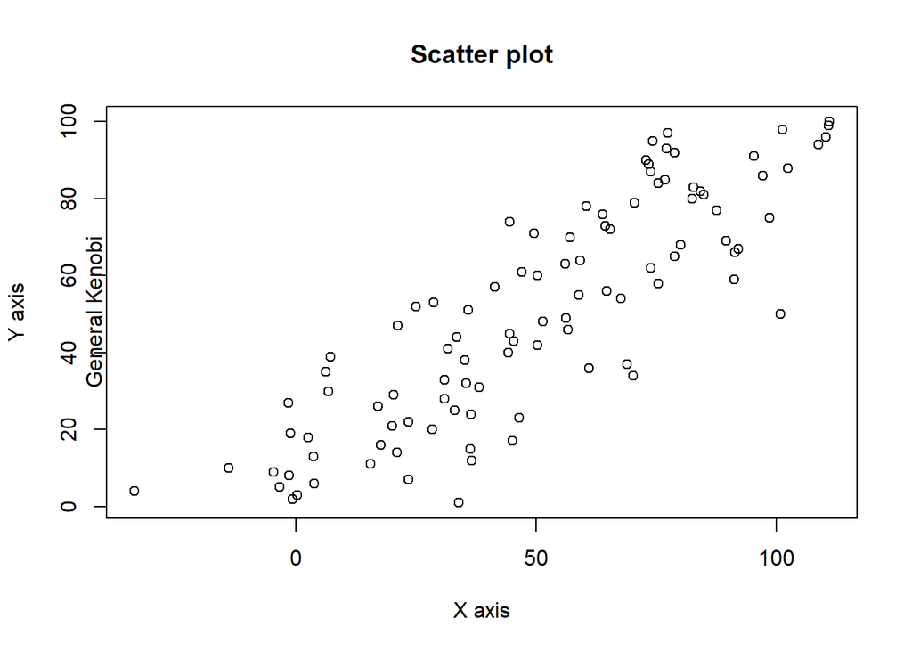

```r
plot(x1,y1, main = "Scatter plot", xlab = "X axis", ylab = "Y axis")
mtext(side=2,text=paste("General", "Kenobi"))
```

7. cor() calculates the correlation between two vectors. Pearson correlation is a measure of the linear correlation (dependence) between two variables X and Y. Try using the cor() function on the x1 and y1 variables.

```r
cor(x1,y1)
```

```
## [1] 0.855402
```

8. Try to use mtext(),cor() and paste() to display the correlation coefficient on your scatter plot.

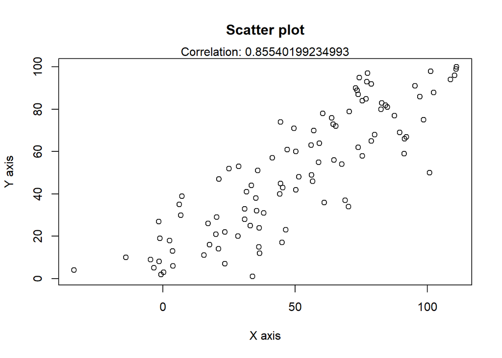

```r
plot(x1,y1, main = "Scatter plot", xlab = "X axis", ylab = "Y axis")
mtext(side=3,text=paste("Correlation:", cor(x1,y1)))
```

9. Change the colors of your plot using the col argument. Ex: plot(x,y,col=“red”).

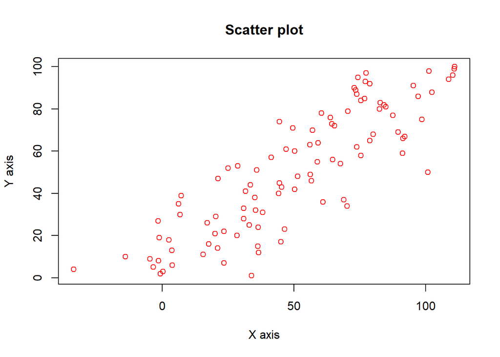

```r
plot(x1,y1, main = "Scatter plot", xlab = "X axis", ylab = "Y axis", col = "red")
```

10. Use pch=19 as an argument in your plot() command.

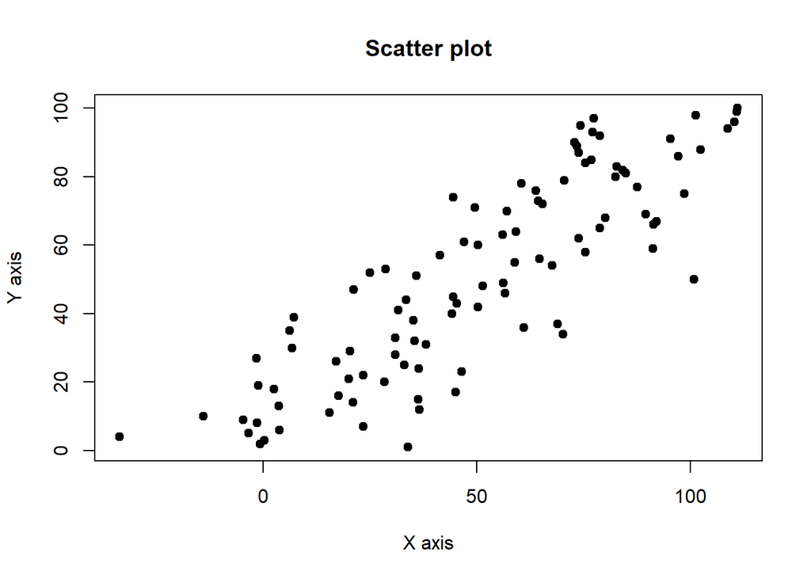

```r
plot(x1,y1, main = "Scatter plot", xlab = "X axis", ylab = "Y axis", pch = 19)
```

11. Use pch=18 as an argument to your plot() command.

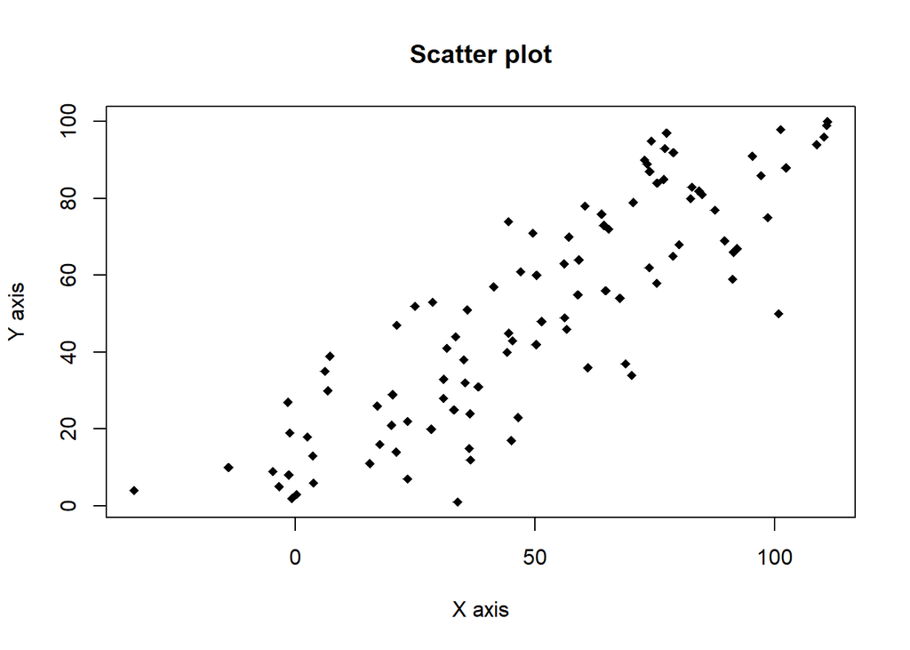

```r
plot(x1,y1, main = "Scatter plot", xlab = "X axis", ylab = "Y axis", pch = 18)
```

12. Make a histogram of x1 with the hist() function. A histogram is a graphical representation of the data distribution.

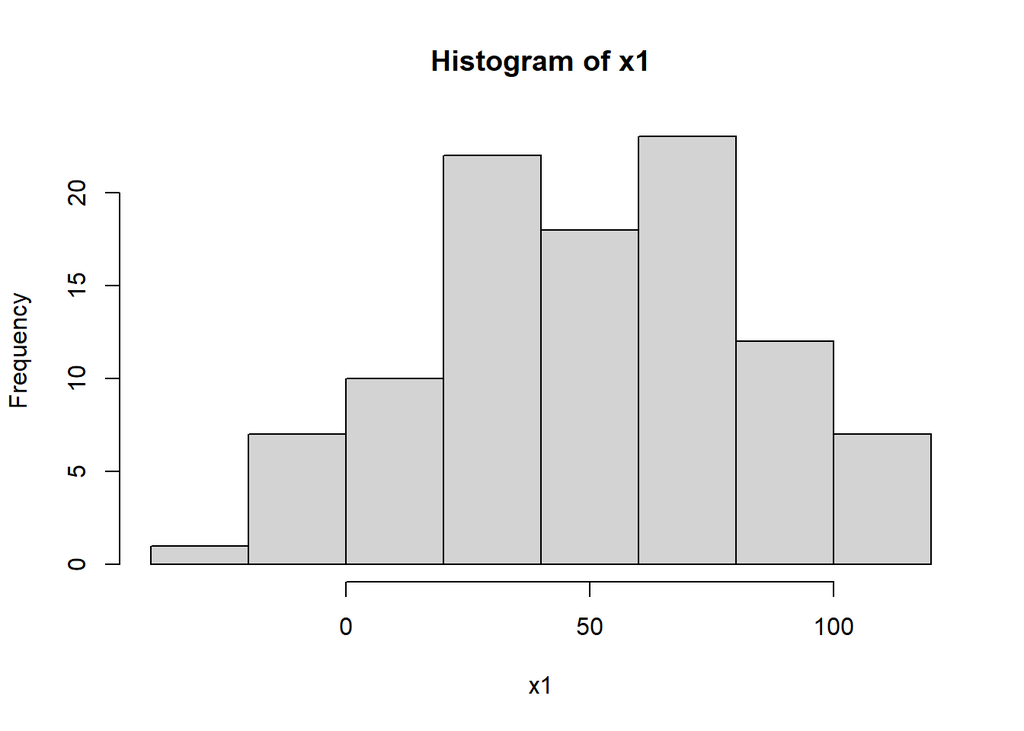

```r
hist(x1)
```

13. You can change colors with ‘col’, add labels with ‘xlab’, ‘ylab’, and add a ‘title’ with ‘main’ arguments. Try all these in a histogram.

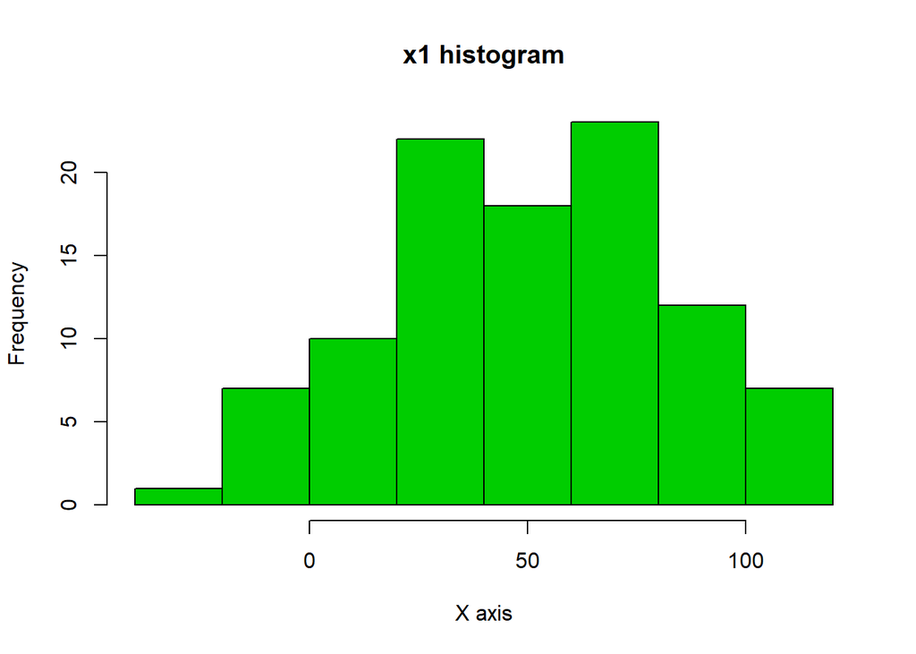

```r
hist(x1, main = "x1 histogram", col = "green3", xlab = "X axis", ylab = "Frequency")
```

14. Make a boxplot of y1 with boxplot().

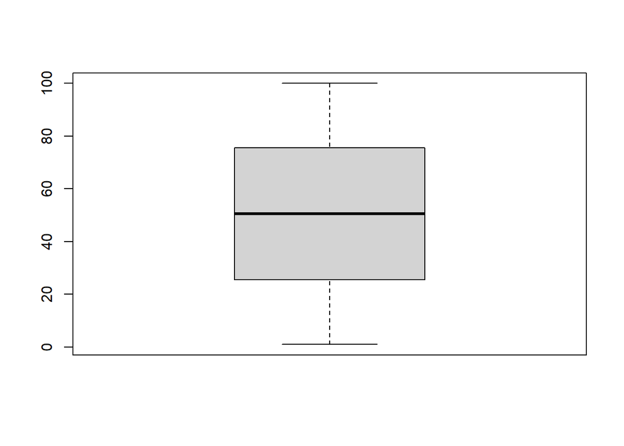

```r
boxplot(y1)
```

15. Make boxplots of x1 and y1 vectors in the same plot.

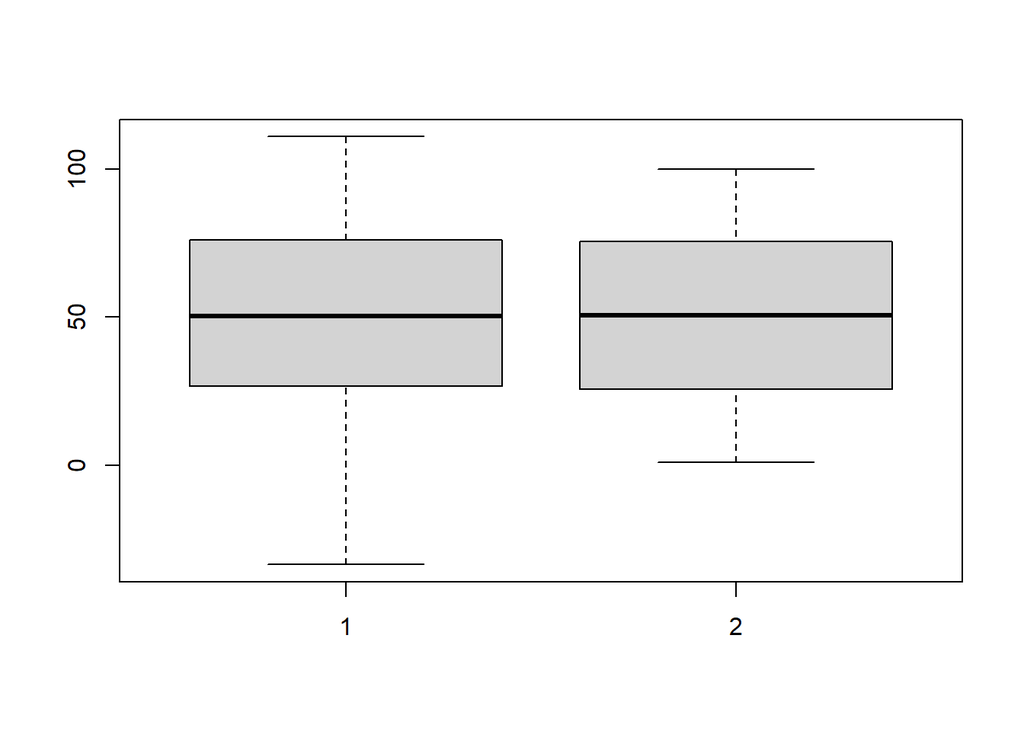

```r
boxplot(x1, y1)
```

16. In boxplot, use the horizontal = TRUE argument.

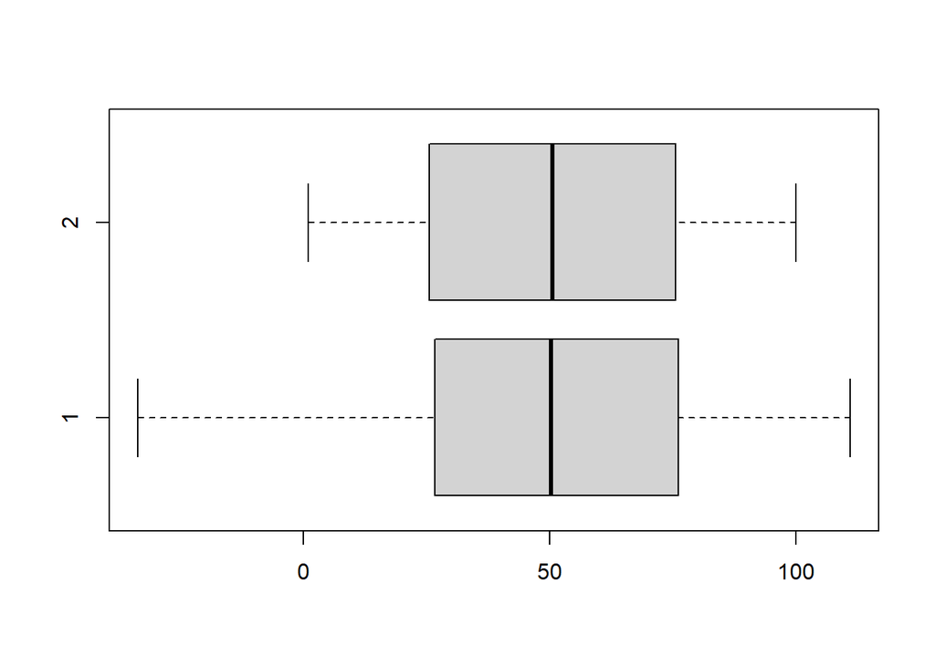

```r
boxplot(x1, y1, horizontal = TRUE)
```

17. Make multiple plots with par(mfrow=c(2,1)) • run par(mfrow=c(2,1)) • make a boxplot • make a histogram

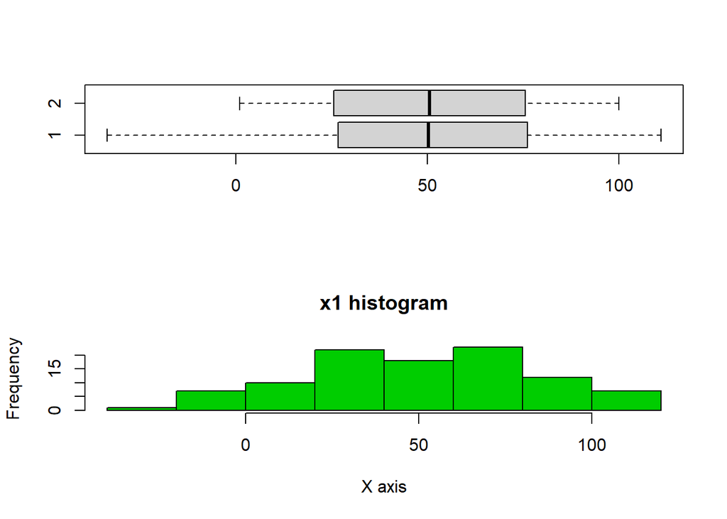

```r
par(mfrow=c(2,1))
boxplot(x1, y1, horizontal = TRUE)
hist(x1, main = "x1 histogram", col = "green3", xlab = "X axis", ylab = "Frequency")
```

18. Do the same as above but this time with par(mfrow=c(1,2)).

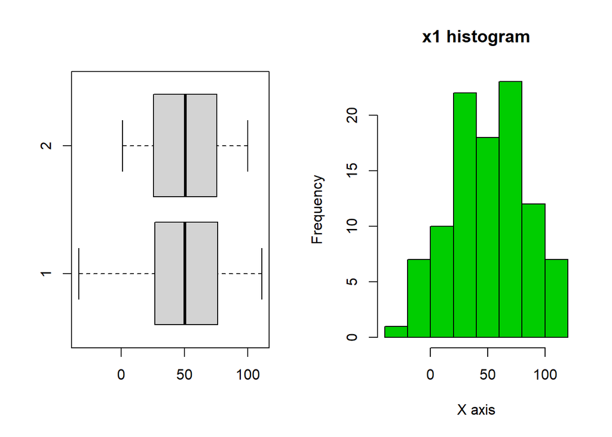

```r
par(mfrow=c(1,2))
boxplot(x1, y1, horizontal = TRUE)
hist(x1, main = "x1 histogram", col = "green3", xlab = "X axis", ylab = "Frequency")
```

19. Save your plot using the “Export” button in Rstudio.
20. You can make a scatter plot showing the density of points rather than points themselves. If you use points it looks like this

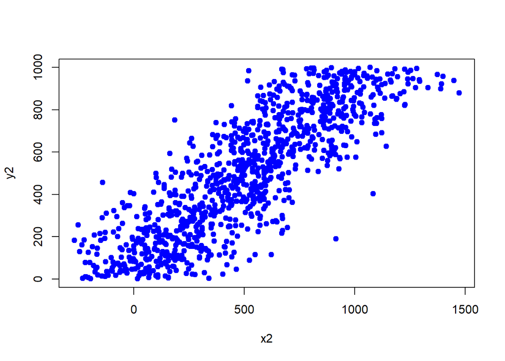

```r
x2=1:1000+rnorm(1000,mean=0,sd=200)
y2=1:1000
plot(x2,y2,pch=19,col="blue")
```

If you use the smoothScatter() function, you get the densities.

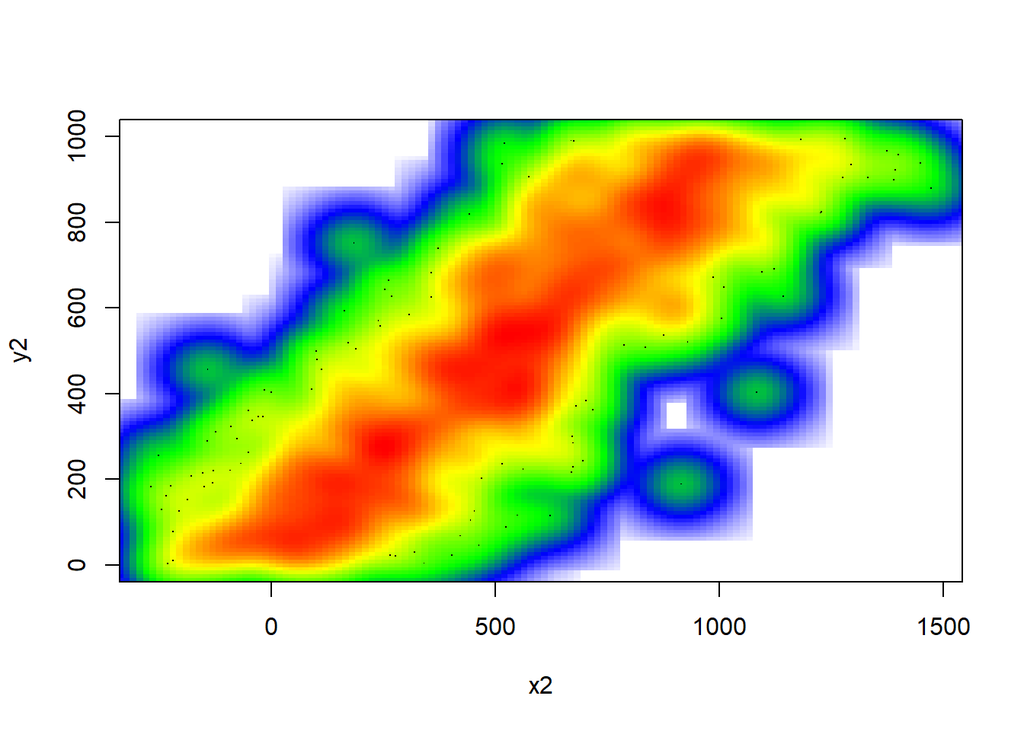

```r
smoothScatter(x2,y2,
colramp=colorRampPalette(c("white","blue",
"green","yellow","red")))
```

Now, plot with the colramp=heat.colors argument and then use a custom color scale using the following argument.

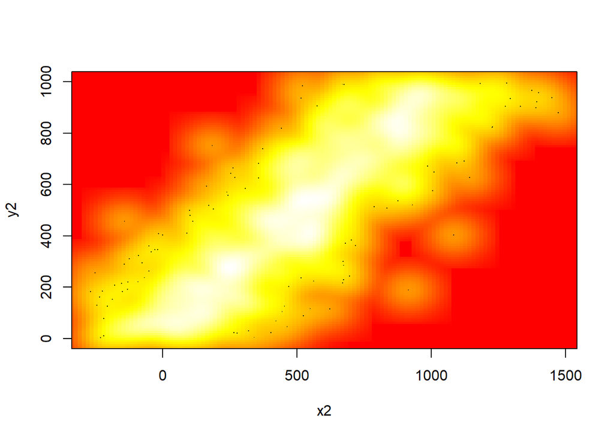

```r
smoothScatter(x2,y2, colramp = heat.colors)
```

and then use a custom color scale

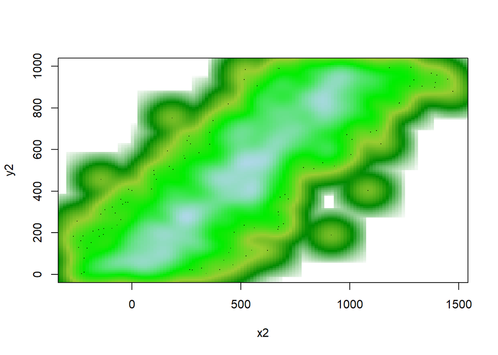

```r
smoothScatter(x2,y2, colramp = colorRampPalette(c("white","green4", "yellowgreen","green2","lightblue")))
```

## Functions and control structures (for, if/else, etc.)

Read CpG island data as shown below for the rest of the exercises.

```r
cpgtFilePath=system.file("extdata", "CpGi.table.hg18.txt", package="compGenomRData")
cpgi=read.table(cpgtFilePath,header=TRUE,sep="\t")
head(cpgi)
```

```
##   chrom chromStart chromEnd     name length cpgNum gcNum perCpg perGc obsExp
## 1  chr1      18598    19673 CpG: 116   1075    116   787   21.6  73.2   0.83
## 2  chr1     124987   125426  CpG: 30    439     30   295   13.7  67.2   0.64
## 3  chr1     317653   318092  CpG: 29    439     29   295   13.2  67.2   0.62
## 4  chr1     427014   428027  CpG: 84   1013     84   734   16.6  72.5   0.64
## 5  chr1     439136   440407  CpG: 99   1271     99   777   15.6  61.1   0.84
## 6  chr1     523082   523977  CpG: 94    895     94   570   21.0  63.7   1.04
```

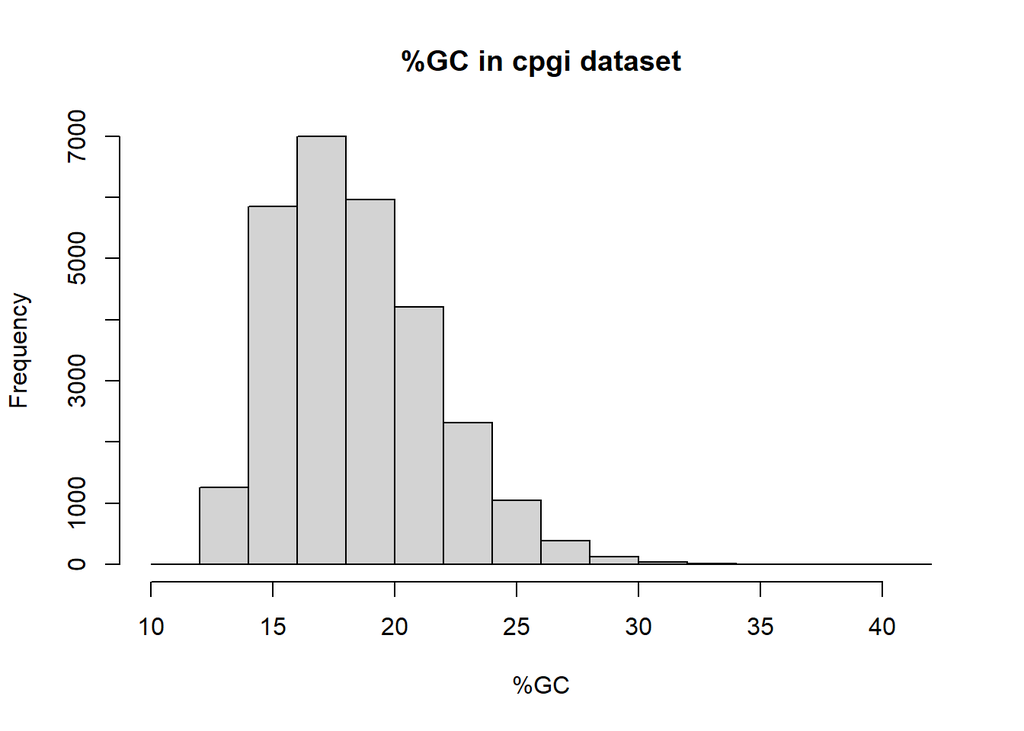

```r
hist(cpgi$perCpg, main = "%GC in cpgi dataset", xlab = "%GC" )
```

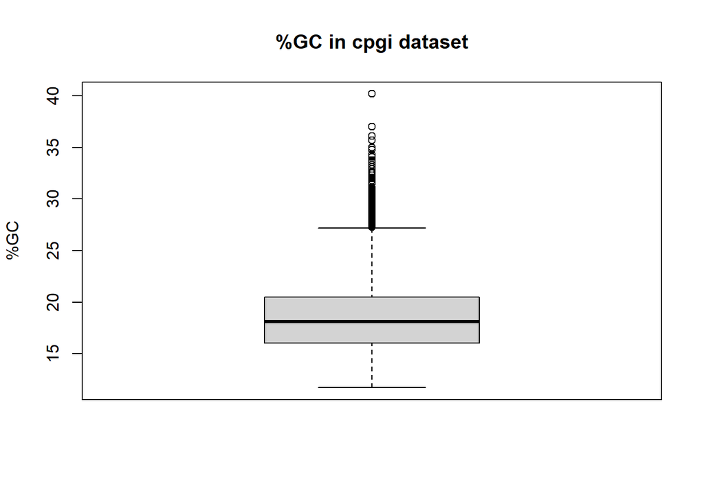

```r
boxplot(cpgi$perCpg, main = "%GC in cpgi dataset", ylab = "%GC" )
```

3. Use if/else structure to decide if the given GC percent is high, low or medium. If it is low, high, or medium: low < 60, high>75, medium is between 60 and 75; use greater or less than operators, < or >.  
   Fill in the values in the code below, where it is written ‘YOU_FILL_IN’

```r
GCper=65
# check if GC value is lower than 60,
# assign "low" to result
if(GCper < 60){
        result="low"
        cat("low")
} else if(GCper > 75) { # check if GC value is higher than 75,
        #assign "high" to result
        result="high"
        cat("high")
} else{ # if those two conditions fail then it must be "medium"
        result="medium"
}
result
```

```
## [1] "medium"
```

4. Write a function that takes a value of GC percent and decides if it is low, high, or medium: low < 60, high>75, medium is between 60 and 75. Fill in the values in the code below, where it is written ‘YOU_FILL_IN’.

```r
GCclass<-function(my.gc){
if(my.gc < 60){
        result="low"
} else if(my.gc > 75) { # check if GC value is higher than 75,
        #assign "high" to result
        result="high"
} else{ # if those two conditions fail then it must be "medium"
        result="medium"
}
return(result)
}
GCclass(10) # should return "low"
```

```
## [1] "low"
```

```r
GCclass(90) # should return "high"
```

```
## [1] "high"
```

```r
GCclass(65) # should return "medium"
```

```
## [1] "medium"
```

5. Use a for loop to get GC percentage classes for gcValues below. Use the function you wrote above.

```r
gcValues=c(10,50,70,65,90)
for( i in gcValues){
        print(GCclass(i))
}
```

```
## [1] "low"
## [1] "low"
## [1] "medium"
## [1] "medium"
## [1] "high"
```

6. Use lapply to get GC percentage classes for gcValues.

```r
lapply(gcValues, GCclass)
```

```
## [[1]]
## [1] "low"
##
## [[2]]
## [1] "low"
##
## [[3]]
## [1] "medium"
##
## [[4]]
## [1] "medium"
##
## [[5]]
## [1] "high"
```

7. Use sapply to get values to get GC percentage classes for gcValues.

```r
sapply(gcValues, GCclass)
```

```
## [1] "low"    "low"    "medium" "medium" "high"
```

8. Is there a way to decide on the GC percentage class of a given vector of GCpercentages without using if/else structure and loops ? if so, how can you do it? HINT: Subsetting using < and > operators.

```r
set.seed(42)
gcValues = data.frame(perCpg = rnorm(100, 65, 10))
gcValues$perCpg_class = "medium"

gcValues$perCpg_class[gcValues$perCpg > 75] = "high"
gcValues$perCpg_class[gcValues$perCpg < 60] = "low"

gcValues$perCpg_class = factor(gcValues$perCpg_class, levels = c("low", "medium", "high"))

head(gcValues, n = 10)
```

```
##      perCpg perCpg_class
## 1  78.70958         high
## 2  59.35302          low
## 3  68.63128       medium
## 4  71.32863       medium
## 5  69.04268       medium
## 6  63.93875       medium
## 7  80.11522         high
## 8  64.05341       medium
## 9  85.18424         high
## 10 64.37286       medium
```

```r
summary(gcValues$perCpg_class)
```

```
##    low medium   high
##     28     55     17
```